# **Introduction to Statistics and Computation with Data: AppleBread Problem Solution 2**

Daibik Barik (Bmat2316)

2024-03-22

```r
#set.seed(2024)
library(tidyverse)
library(viridis)
```

```r
library(ggplot2)
library(gganimate)
library(gifski)
```

**Challenge Problem 2]**

```r
##Functioning of the model
process<- function(A, K) {
  #Creation
  for(i in 1:K) {
    boundary= c()
    for(element in A) {
      if(! (element +1) %in% A) {
        boundary<- append(boundary, (element+1))
      }
      if(! (element -1) %in% A) {
        boundary<- append(boundary, (element-1))
      }
    }
    A<- append(A, sample(boundary, 1))
  }

  #Annihilation
  for(i in 1:(K-1)) {
    length= length(A)
    remove_index= sample(1:length, 1)
    A<- A[-c(remove_index)]
  }
  return(A)
}
```

# 1 .

Let the number of elements of $A_n$ be $N$ at time $n$.

At time $n+1$, $K$ new sites are added one by one, making the total number of occupied sites $N+K$. After that $K-1$ sites are chosen uniformly from those $N+K$ sites and are deleted, one by one.

Therefore, in the end, the total number of sites result to $N+K-(K-1)= N+1$.

# 2 .

```r
##Code Run for 100 steps
A= c(0); K= 3
A_n= list(A)
for(n in 1:100) {
  A= process(A, K)
  A_n[[n+1]]= A
}
#print(length(A)) for verification
```

As per the discussion with Siva in class of $22^{nd}$ March $2024$, this model is being represented for $n=100$ instead of $n=1000$, as in the second case the plot is indistinguishable from a straight line.

Siva also suggested the use of “Gaps” instead of the “Occupied Sites” to one of our fellow students. But personally I didn’t like the plot at all since it didn’t help to provide an intuition, or what was in this case, not a proper simlation of the Model.

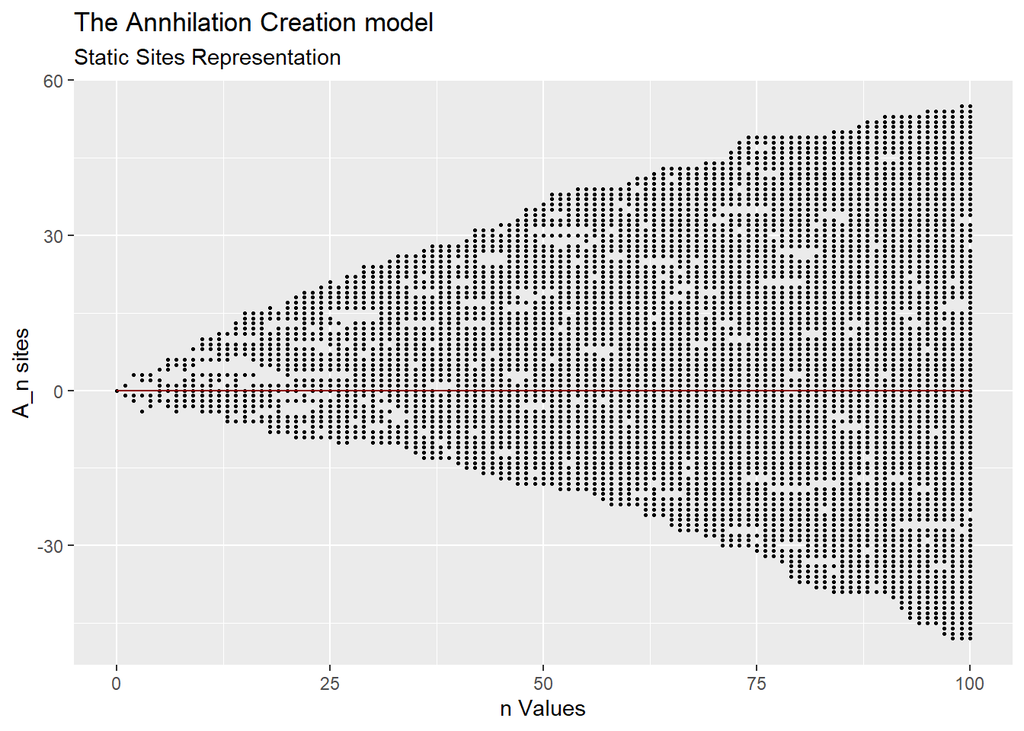

```r
##Static Representation of Model
x_values= c(0)
for(i in 1:100) {
  x_values= c(x_values, rep(i,i+1))
}
A_n_flattened= unlist(A_n, use.names= FALSE)
df= data.frame(
  x_cords= x_values,
  y_cords= A_n_flattened
)
ggplot(data= df) +
  geom_point(mapping= aes(x= x_cords, y= y_cords),
             size= 1/2) +
  geom_line(mapping= aes(x= x_cords, y= 0), col= "darkred")+
  xlab("n Values") + ylab("A_n sites") +
  labs(title= "The Annhilation Creation model",
       subtitle= "Static Sites Representation" )
```

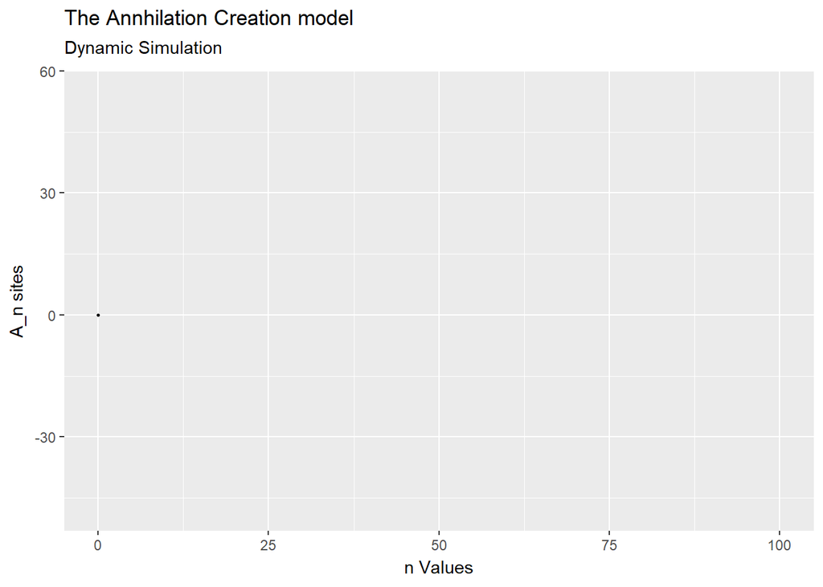

```r
##Dynamic Simulation of model
model= ggplot(data= df) +
  geom_point(mapping= aes(x= x_cords, y= y_cords),
             size= 1/2) +
  transition_manual(x_values)+
  xlab("n Values") + ylab("A_n sites") +
  labs(title= "The Annhilation Creation model",
       subtitle= "Dynamic Simulation" )
animate(model, fps= 7.5)
```

# 3 .

```r
##Functioning of L(A_n) and G2(A_n)
L<- function(A) {
  A_sorted= sort(A)
  A_gaplength= diff(A_sorted)-1
  sum(A_gaplength)
}

G2<- function(A) {
  A_sorted= sort(A)
  A_gaplength= diff(A_sorted)-1
  sum(A_gaplength >=2)
}
```

```r
##Finding L_n and G2_n for n=1000 over 100 trials
L_tn= matrix(nrow= 100, ncol= 1000)
G2_tn= matrix(nrow= 100, ncol= 1000)
trials= 1:100; n_values= 1:1000
for(t in trials) {
  A= c(0); K= 3
  for(n in n_values) {
    A= process(A, K)
    L_tn[t,n]= L(A)
    G2_tn[t,n]= G2(A)
  }
}
```

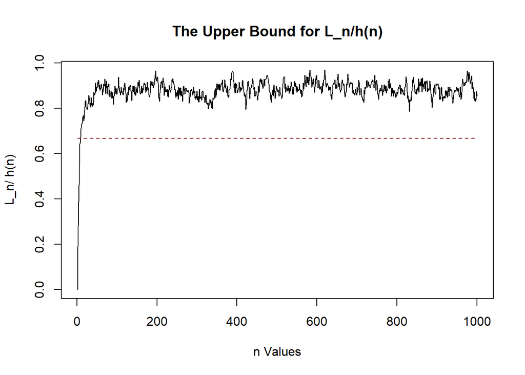

```r
##Showing (by plot) that L_n= O(h(n))
L_n= c()
for(n in n_values) {
  L_n[n]= mean(L_tn[,n])
}
h<- function(n) {
  log(n)/ log(log(n))
}
n_val<- 1:1001
plot(n_val, c(0, L_n/h(n)),
     xlab= "n Values", ylab= "L_n/ h(n)",
     main= "The Upper Bound for L_n/h(n)", type='l')
y_lim<- 0*n_val +2/3
lines(n_val, y_lim, col = "darkred", lty = 2)
text(x= 5, y= 7/5,
     labels= "y= 3/2", col= "darkred")
```

We try to show, as Theorem $2.1.2$ (Dorothea Maria Eberz-Wagner 1999), that
$$\mathbb{P}\left[G^{(2)}(A_n)= 1\; \text{ i.o.}\right]= 1$$
$$\implies \mathbb{P}\left[\;\forall N\geq 1\;
\exists n\geq N\; s.t.\; G^{(2)}(A_n)= 1\right]= 1$$
$$\implies \mathbb{P}\left[\;\forall N\geq 1\;
\exists n\geq N\; s.t.\; \overline{G^{(2)}(A_n)}= G^{(2)}_n(A_n)=
1\right]= 1$$

Trying to find the empirical probability through statistics….

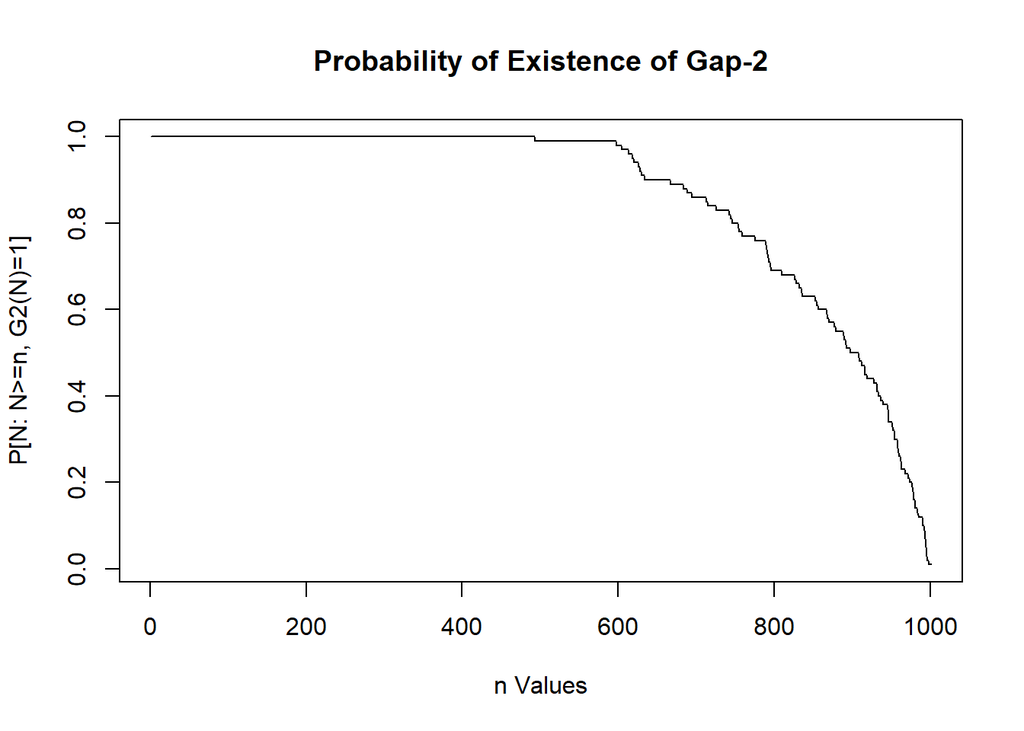

```r
##Showing by plot P[G2_n(A_n)=1 i.o.]= 1

pG2_1= matrix(nrow= 100, ncol= 1000)
for(t in trials) {
  max_g2n_1= 1
  for(n in n_values) {
    if(G2_tn[t, n]== 1) {
      max_g2n_1= n
    }
  }
  for(n in n_values) {
    if(n<= max_g2n_1) {
      pG2_1[t,n]= 1
    } else {
      pG2_1[t,n]= 0
    }
  }
}
pG2n_1= c()
for(n in n_values) {
  pG2n_1[n]= mean(pG2_1[,n])
}
#print(pG2n_1)
plot(n_val, c(1, pG2n_1),
     xlab= "n Values", ylab= "P[N: N>=n, G2(N)=1]",
     main= "Probability of Existence of Gap-2", type = "l")
```

We see for lower values of $n$, $\mathbb{P}= 1$. But as we go higher, the probability decreases since there are limited number of samples taken into consideration.

Therefore, if we take the whole Natural Number line, we can say $\mathbb{P}\left[G^{(2)}(A_n)= 1\; \text{ i.o.}\right]= 1$

# References

Dorothea Maria Eberz-Wagner. 1999. *Discrete Growth Models*. Thesis: University of Washington. https://arxiv.org/pdf/math/9908030.pdf.